# Average BMI in Middle-Income Adults

Morgan Ehman

## Question And Audience

**Audience:** Public health program managers who are not data specialists, receiving a short equity briefing on middle-income adults.

**Question:** How did average body mass index (BMI) among middle-income adults aged 20 to 80 differ across NHANES survey waves in the classroom dataset?

**Why it matters:** The answer can help program managers decide whether to include middle-income adults when planning healthy-weight programs.

## Evidence

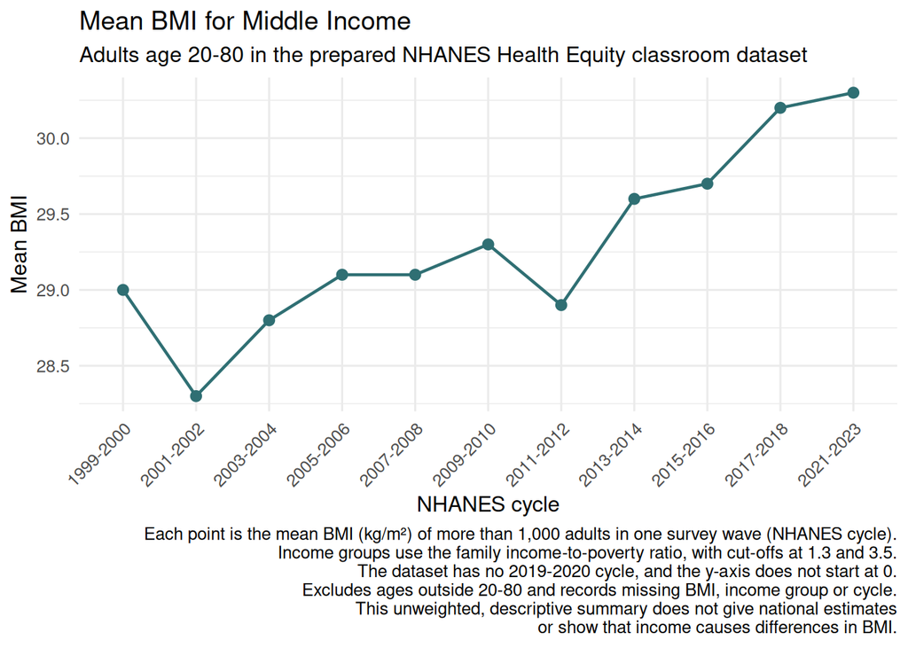

Source: prepared classroom snapshot derived from CDC/NCHS NHANES public-use data (Centers for Disease Control and Prevention, National Center for Health Statistics 2026). Results are descriptive and unweighted.

## Takeaway

In this classroom dataset, middle-income adults surveyed in 2021-2023 had a higher average BMI (30.3) than those surveyed in 1999-2000 (29.0).

## Limitation And Next Step

**Limitation:** This unweighted, descriptive summary does not give national estimates or show why average BMI differed between survey waves. Each survey wave included different people, so it does not follow the same adults over time. The graph’s y-axis does not start at 0, so the change can look bigger than it is.

**Next step:** Before using these results in planning, ask for an analysis that uses the NHANES survey weights, which adjust for how people were chosen for the survey, so the averages can represent US adults.

**AI-use note:** AI (Claude) helped draft and simplify the slide wording and layout. I checked each number against the A7 figure and built the limitation from my A7 work and peer feedback.

## References

Centers for Disease Control and Prevention, National Center for Health Statistics. 2026. *National Health and Nutrition Examination Survey*. https://wwwn.cdc.gov/nchs/nhanes/.